# AVC_BCO_bone_nondup_genomic_analysis

Max Cummins

2023-04-10

## File summary

A GitHub repository available at https://github.com/maxlcummins/bonechook contains all scripts and files required to rerun analysis detailed in this document.

Below are the files associated with this research project and report.

### Genomic data

Genomic data was generated using snakemake using the following [snakefile](https://github.com/maxlcummins/pipelord/tree/main/workflow/Snakefile).

```bash
#Run our genomics workflow
nohup snakemake --use-conda --conda-frontend mamba -T 10 --rerun-incomplete -s workflow/Snakefile --configfile config/AVC_FH.yaml -j 36 -k -p > /projects/AusGEM/Users/Max/AVC_FH/logs/snakemake/AVC_FH_Genotype_all.out.log 2> /projects/AusGEM/Users/Max/AVC_FH/logs/snakemake/AVC_FH_Genotype_all.err.log &

# Jupiter6
# JobID = 41101
# Fri Jun  3 22:38:03 AEST 2022
```

### Mashtree

We also generated a mashtree in our QC step, but we will now generate another with only the ones which passed QC.

```bash
#Deactivate our old environment
source deactivate

#Activate our new environment
source activate mashtree

#Run mashtree
nohup mashtree --mindepth 0 --tempdir /tmp/mashtree_QC_pass --numcpus 20 --outmatrix /projects/AusGEM/Users/Max/AVC_FH/analysis/mashtree/mashtree_QC_pass.matrix --outtree /projects/AusGEM/Users/Max/AVC_FH/analysis/mashtree/mashtree_QC_pass.tree /projects/AusGEM/Users/Max/AVC_FH/data/symlink_QC_pass/*.R1.fastq.gz > /projects/AusGEM/Users/Max/AVC_FH/logs/mashtree/mashtree_QC_pass.out.log 2> /projects/AusGEM/Users/Max/AVC_FH/logs/mashtree/mashtree_QC_pass.err.log &

# Jupiter8
# JobID = 91625
# Mon Jun  6 11:52:44 AEST 2022
```

Now we generate the tree consisting of the BCO samples we filtered for in our QC script. These samples are different from the full BCO cohort as they:

- Are limited to one sample per bird
- Are only sourced from bone sites

```bash
#Deactivate our old environment
source deactivate

#Activate our new environment
source activate mashtree

#Run mashtree
nohup mashtree --mindepth 0 --tempdir /tmp/mashtree_QC_pass_AVC_BCO_bone_nondup --numcpus 6 --outmatrix /projects/AusGEM/Users/Max/AVC_FH/analysis/mashtree/mashtree_QC_pass_AVC_BCO_bone_nondup.matrix --outtree /projects/AusGEM/Users/Max/AVC_FH/analysis/mashtree/mashtree_QC_pass_AVC_BCO_bone_nondup.tree /projects/AusGEM/Users/Max/AVC_FH/data/sampled_bonesites_and_AVC/*.R1.fastq.gz > /projects/AusGEM/Users/Max/AVC_FH/logs/mashtree/mashtree_QC_pass_AVC_BCO_bone_nondup.out.log 2> /projects/AusGEM/Users/Max/AVC_FH/logs/mashtree/mashtree_QC_pass_AVC_BCO_bone_nondup.err.log &

# Jupiter5
# JobID = 245746
# Tue Jun  7 13:58:55 AEST 2022
```

Now we run our pangenomics workflow to generate our phylogeny and pangenome for our bone nondupe cohort (with AVC).

```bash
#Run our pangenomics/phylogenetic workflow
nohup snakemake --use-conda --conda-frontend mamba -T 10 --rerun-incomplete -s workflow/Treebuild_panaroo.smk --configfile config/AVC_FH.yaml -j 30 -k -p > /projects/AusGEM/Users/Max/AVC_FH/logs/snakemake/AVC_FH_pangenome_bone_nondup.out.log 2> /projects/AusGEM/Users/Max/AVC_FH/logs/snakemake/AVC_FH_pangenome_bone_nondup.err.log &

# Jupiter12
# JobID = 35408
# Wed Jun 15 09:41:44 AEST 2022
```

```bash
#Run our pangenomics/phylogenetic workflow
nohup snakemake --use-conda --conda-frontend mamba --rerun-incomplete -s workflow/Treebuild_panaroo.smk --configfile config/AVC_FH.yaml -j 30 -k -p > /projects/AusGEM/Users/Max/AVC_FH/logs/snakemake/AVC_FH_pangenome_bone_nondup.out2.log 2> /projects/AusGEM/Users/Max/AVC_FH/logs/snakemake/AVC_FH_pangenome_bone_nondup.err2.log &

# Jupiter15
# JobID = 43678
# Thu Jun 16 09:56:35 AEST 2022
```

Now we run it again for our FH isolates, and FH ST117, ST95, ST69 and ST57

```bash
#Run our pangenomics/phylogenetic workflow
nohup snakemake --use-conda --conda-frontend mamba --rerun-incomplete -s workflow/Treebuild_panaroo.smk --configfile config/AVC_FH.yaml -j 30 -k -p > /projects/AusGEM/Users/Max/AVC_FH/logs/snakemake/FH_only.out.log 2> /projects/AusGEM/Users/Max/AVC_FH/logs/snakemake/FH_only.err.log &

# Jupiter10
# JobID = 19994
# Mon Jul  4 11:07:48 AEST 2022
```

## Genomic analysis

After downloading all of the resulting files from the remote server we are ready to begin our QC.

## Collection breakdown

We will start by producing some figures relating to the collection composition:

### Breakdown by year

[figure not shown]

```r
library(VennDiagram)

#cMake the plot
venn.diagram(
  x = list(
    genometa %>% filter(Collection =="BCO") %>% dplyr::select(ST) %>% unlist(),
    genometa %>% filter(Collection =="AVC") %>% dplyr::select(ST) %>% unlist()
    ),
  category.names = c("BCO", "AVC"),
  filename = 'venn.png',
  output = TRUE ,
          imagetype="png" ,
          height = 480 ,
          width = 480 ,
          resolution = 300,
          compression = "lzw",
          lwd = 1,
          col=c("#440154ff", '#21908dff'),
          fill = c(alpha("#440154ff",0.3), alpha('#21908dff',0.3)),
          cex = 0.5,
          fontfamily = "sans",
          cat.cex = 0.3,
          cat.default.pos = "outer",
          cat.pos = c(-27, 27),
          cat.dist = c(0.055, 0.055),
          cat.fontfamily = "sans",
          cat.col = c("#440154ff", '#21908dff')
        )
```

```
## [1] 1
```

```r
library(ggpubr)

count_sites_by_ST <- genometa %>% filter(Collection == "BCO") %>% group_by(ST, Bird_Gross_Necropsy_ID) %>% summarise(counts = n()) %>% mutate(ST = paste0("ST", ST))

ST_by_clermontype <- genometa %>% group_by(ST, Clermont_type) %>% summarise(counts = n())

ST_by_clermontype <- ST_by_clermontype %>%
        group_by(ST) %>%
        filter(counts == max(counts)) %>%
        arrange(ST,Clermont_type, counts) %>%
        dplyr::select(-counts) %>%
        mutate(ST = paste0("ST", ST))

count_sites_by_ST <- left_join(count_sites_by_ST, ST_by_clermontype) %>% arrange(match(count_sites_by_ST$ST, ST_by_clermontype$ST))

ST_order <- count_sites_by_ST %>% dplyr::select(ST, Clermont_type) %>% arrange(Clermont_type) %>% unique() %>% pull(ST)

count_sites_by_ST$ST <- factor(count_sites_by_ST$ST, levels = ST_order)

count_of_st <- genometa %>% filter(Collection == "BCO") %>% group_by(ST) %>% summarise(counts = n()) %>% mutate(ST = paste0("ST", ST)) %>% filter(counts > 3)

count_sites_by_ST <- count_sites_by_ST %>% filter(ST %in% count_of_st$ST)

count_sites_by_ST$Clermont_type <- factor(count_sites_by_ST$Clermont_type, levels = c("A","B1","B2","D","E", "G"))


p <- ggboxplot(count_sites_by_ST, x = "ST", y = "counts", color = "Clermont_type", palette = "jco",
          add = "jitter")
```

[figure not shown]

```r
vir_df <- BCO_APEC_simple_summary_N90L90 %>% dplyr::select(name, starts_with('vfdb'), starts_with('EC_'))

vir_df <- vir_df %>% column_to_rownames('name') %>% t() %>% as.data.frame()

vir_df <- vir_df %>% rownames_to_column('gene')

vir_df <- vir_df %>% mutate(gene = str_replace(gene, 'vfdb_|EC_custom_', ''))

vir_df <- vir_df %>% column_to_rownames('gene') %>% t()

vir_df[vir_df > 1] <- 1

vir_df <- as.data.frame(vir_df)

vir_df <- vir_df %>% dplyr::select(matches("astA"),
matches("cba"),
matches("celb"),
matches("cma"),
matches("cvaA"),
matches("cvaB"),
matches("cvaC"),
matches("cvi"),
matches("eilA"),
matches("eitA"),
matches("eitB"),
matches("eitC"),
matches("eitD"),
matches("etsA"),
matches("fimH"),
matches("fyuA"),
matches("gad"),
matches("gimB_marker"),
matches("hek"),
matches("hlyE"),
matches("hylF"),
matches("ibeA"),
matches("iha"),
matches("ipaH"),
matches("ireA"),
matches("iroN"),
matches("irp2"),
matches("iss"),
matches("iucD"),
matches("iutA"),
matches("kpsM"),
matches("kpsMT_II"),
matches("kpsMT_III"),
matches("lpfA"),
matches("malX"),
matches("mchB"),
matches("mchC"),
matches("mchF"),
matches("mcmA"),
matches("neuC"),
matches("ompT"),
matches("papA"),
matches("papB"),
matches("papC"),
matches("papD"),
matches("papE"),
matches("papF"),
matches("papGII"),
matches("papH"),
matches("papI"),
matches("papJ"),
matches("papK"),
matches("pic"),
matches("shiD"),
matches("sitA"),
matches("tia"),
matches("traT"),
matches("tsh"),
matches("usp"),
matches("vat"),
matches("yeeT")
)

vir_df <- vir_df %>%
        rowwise() %>%
        mutate(fimH_new= sum(fimH, fimH_CP015076.1, na.rm = T)) %>%
        dplyr::select(-fimH, -fimH_CP015076.1) %>%
        mutate(fyuA_new= sum(fyuA, fyuA_Z35106.1, na.rm = T)) %>%
        dplyr::select(-fyuA, -fyuA_Z35106.1) %>%
        mutate(ibeA_new= sum(ibeA, ibeA_AY248744.1, na.rm = T)) %>%
        dplyr::select(-ibeA, -ibeA_AY248744.1) %>%
        mutate(irp2_new = sum(irp2, `irp2_(gi:117624162)|VFG012550`, `irp2_(gi:218695586)|VFG034095`, `irp2_(gi:218705472)|VFG034101`, `irp2_(gi:222156713)|VFG034107`, `irp2_(gi:386629711)|VFG034099`, `irp2_(gi:387607663)|VFG034096`, `irp2_(gi:45441468)|VFG003119`, na.rm = T)) %>%
        dplyr::select(-irp2, -`irp2_(gi:117624162)|VFG012550`, -`irp2_(gi:218695586)|VFG034095`, -`irp2_(gi:218705472)|VFG034101`, -`irp2_(gi:222156713)|VFG034107`, -`irp2_(gi:386629711)|VFG034099`, -`irp2_(gi:387607663)|VFG034096`, -`irp2_(gi:45441468)|VFG003119`) %>%
        mutate(iss_new= sum(`iss_type2_ETEC-B7a_NZ_AAJT00000000`, iss_type3_UTI89_CP000243, na.rm = T)) %>%            dplyr::select(-`iss_type2_ETEC-B7a_NZ_AAJT00000000`, -iss_type3_UTI89_CP000243) %>%
        mutate(iucD_new = sum(iucD, iucD_AY545598.5, na.rm = T)) %>%
        dplyr::select(-iucD, -iucD_AY545598.5) %>%
        mutate(iutA_new = sum(iutA, iutA_KU578032.1, na.rm = T)) %>%
        dplyr::select(-iutA, -iutA_KU578032.1) %>%
        mutate(`kpsMT(II)_new` = sum(`kpsMT(II)_K1:AE014075.1|CFT073|3527848-3529293`, `kpsMT(II)_K2:CP000468.1:|APEC-O1|3376659-3378102`, `kpsMT(II)_K5:CP002212.1|3385642-3387090`, na.rm = T)) %>%
        dplyr::select(-`kpsMT(II)_K1:AE014075.1|CFT073|3527848-3529293`, -`kpsMT(II)_K2:CP000468.1:|APEC-O1|3376659-3378102`, -`kpsMT(II)_K5:CP002212.1|3385642-3387090`) %>%
        mutate(neuC_new = sum(neuC, neuC_CP007275.1, na.rm = T)) %>%
        dplyr::select(-neuC, -neuC_CP007275.1) %>%
        mutate(ompT_new = sum(`ompT_chromosomal_O157-H7_NC_002695`, `ompT_episomal_HM210637.1`, na.rm = T)) %>%
        dplyr::select(-`ompT_chromosomal_O157-H7_NC_002695`, -`ompT_episomal_HM210637.1`) %>%
        dplyr::select(-papB, -papD, -papE, -papF, -papH, -papI, -papJ, -papK)

vir_df <- vir_df %>% mutate(sitA_new = sum(`sitA_(gi:218704670)|VFG034199`, `sitA_(gi:387606979)|VFG034194`, `sitA_(gi:387616520)|VFG034206`, `sitA_(gi:82776740)|VFG013039`,  `sitA_(gi:88770314)|VFG012575`,  `sitA_(gi:91210366)|VFG012573`, na.RM = T)) %>% dplyr::select(-`sitA_(gi:218704670)|VFG034199`, -`sitA_(gi:387606979)|VFG034194`, -`sitA_(gi:387616520)|VFG034206`, -`sitA_(gi:82776740)|VFG013039`,  -`sitA_(gi:88770314)|VFG012575`,  -`sitA_(gi:91210366)|VFG012573`)

vir_df <- vir_df %>% mutate(papC_new = sum(papC, papC_CU928161)) %>% dplyr::select(-papC, -papC_CU928161)

vir_df <- vir_df %>% mutate(tia_new = sum(tia_CP019944.1, tia_CU928161)) %>% dplyr::select(-tia_CP019944.1, -tia_CU928161)

vir_df <- vir_df %>% mutate(usp_new = sum(usp_AB056434, usp_AB056436, usp_AB056437, usp_AB056439)) %>% dplyr::select(-usp_AB056434, -usp_AB056436, -usp_AB056437, -usp_AB056439)

vir_df <- vir_df %>% rename_all(funs(stringr::str_replace_all(., '_.*', '')))

vir_df[vir_df > 1] <- 1

heatmap_vir <- pheatmap(vir_df, cluster_cols = TRUE)
```

```r
vir_df <- vir_df %>% dplyr::select(all_of(heatmap_vir$tree_col$order))

binary_sum_perc_colnames <- function(df){
        df <- vir_df
        oldname <- colnames(df)
        n_w_gene <- colSums(df) %>% as.data.frame() %>% rownames_to_column('name') %>% rename('count' = '.')
        n_total <- nrow(df) %>% as.numeric()
        perc <- scales::percent(x = (n_w_gene$count/n_total), accuracy = 2)
        n_w_gene <- n_w_gene %>% mutate(count = as.character(count))
        n_total <- n_total %>% as.character(n_total)
        colnames(df) <- paste0(n_w_gene$name, " ", n_w_gene$count, "/", n_total, " (", perc, ")")
        return(df)
}

vir_df <- vir_df %>% binary_sum_perc_colnames()

vir_df <- vir_df %>% mutate(across(where(is.numeric), as.character))

vir_df <- vir_df %>% as.data.frame()

rownames(vir_df) <- BCO_APEC_simple_summary_N90L90$name



p2 <- gheatmap(
        p = p1_linear,
        data = vir_df,
        colnames_offset_y = -0.1,
        font.size = 3,
        hjust = 0,
        colnames = TRUE,
        colnames_position = "top",
        colnames_angle = 90,
        offset = 0.025,
        width = 15,
        color = rgb(220, 220, 220, max = 255, alpha = 50)
        ) +
theme(legend.position = "bottom",
        legend.box = "vertical",
        legend.key.size = unit(1, "mm"),
        legend.title = element_blank(),
        legend.text = element_text(size = 8)
        ) +
scale_color_manual(
        values = c(mycolslist, c('0' = 'white', '1' = 'red')),
        na.value = 'grey',
        guide = "none"
        ) +
scale_fill_manual(
        values = c(mycolslist, c('0' = 'white', '1' = 'red')),
        na.value = 'grey',

        ) +
        ylim(NA, 350)
```

## IncF RST analysis

```r
pMLST <- read_delim("analysis/pMLST.txt",
    delim = "\t", escape_double = FALSE,
    trim_ws = TRUE,
    show_col_types = FALSE)

pMLST <- pMLST %>% pivot_wider(id_cols = 'name', names_from = 'pMLST_scheme', values_from = 'pMLST')

genometa <- left_join(genometa, pMLST)

long_inf_rst <- genometa %>% group_by(Collection, incf) %>% summarise(counts = n(), .groups = 'keep') %>% pivot_wider(id_cols = 'incf', names_from = 'Collection', values_from = 'counts') %>% mutate(across(everything(), ~replace_na(.,0)))

long_inf_rst <- long_inf_rst %>% mutate(total = AVC + BCO) %>% mutate(total = paste0(total,"/300 (", scales::percent(total/300, accuracy = 2),')'))


long_inf_rst <- long_inf_rst %>% mutate(AVC = paste0(AVC,"/95 (", scales::percent(AVC/95, accuracy = 2),')'))

long_inf_rst <- long_inf_rst %>% mutate(BCO = paste0(BCO,"/205 (", scales::percent(BCO/205, accuracy = 2),')'))

long_inf_rst<- long_inf_rst %>% mutate(incf = str_replace(incf, pattern = 'C4', replacement = 'F18'))
```

## ColV Stats

```r
contingency_table_ColV_Collection <- table(genometa$Collection, genometa$ColV)

small_subset_tree <- read.tree("analysis/trees/old/mashtree_QC_pass_AVC_BCO_bone_nondup.tree")

small_subset_tree$tip.label <- gsub("\\.R1$","", small_subset_tree$tip.label)

small_subset_genometa <- genometa %>% filter(name %in% small_subset_tree$tip.label)

table(small_subset_genometa$Collection, small_subset_genometa$ColV) %>% chisq.test()
```

```
##
##  Pearson's Chi-squared test with Yates' continuity correction
##
## data:  .
## X-squared = 0.39591, df = 1, p-value = 0.5292
```

```r
chisq.test(contingency_table_ColV_Collection)
```

```
##
##  Pearson's Chi-squared test with Yates' continuity correction
##
## data:  contingency_table_ColV_Collection
## X-squared = 3.0979, df = 1, p-value = 0.07839
```

## ST Table

```r
ST_table <- genometa %>% group_by(ST, Collection) %>% summarise(counts = n())

ST_table <- ST_table %>% pivot_wider(id_cols = 'ST', names_from = 'Collection', values_from = 'counts') %>% mutate(across(everything(), ~replace_na(.,0)))

ST_table <- ST_table %>% mutate(total = AVC + BCO) %>% arrange(desc(total)) %>% mutate(total = paste0(total,"/300 (", scales::percent(total/300, accuracy = 2),')'))


ST_table <- ST_table %>% mutate(AVC = paste0(AVC,"/95 (", scales::percent(AVC/95, accuracy = 2),')'))

ST_table <- ST_table %>% mutate(BCO = paste0(BCO,"/205 (", scales::percent(BCO/205, accuracy = 2),')'))

phylogroup_ST_intersection <- genometa %>% group_by(ST, Clermont_type) %>% summarise(clermontypes = n()) %>% mutate(type_and_count = paste0(Clermont_type, ' (',clermontypes,')')) %>% ungroup %>% group_by(ST) %>% mutate(Phylogroups = paste0(type_and_count, collapse = ",")) %>% dplyr::select(ST, Phylogroups) %>% unique()

ST_phylogroup_table <- inner_join(ST_table, phylogroup_ST_intersection, by = "ST") %>% dplyr::select(ST, Phylogroups, AVC, BCO, total)
```

## Virulence NMDS

```r
library(MASS)
library(vegan)
library(ellipse)
library(grid)
library(gridExtra)
library(dplyr)

#read data into variable data
mds.data <- genometa
rownames(mds.data) <- genometa %>% pull(name)
mds.metadata <- mds.data %>% dplyr::select(1:13, ST_other) %>% rename('Name' = 'name')

vir_df <- vir_df %>% mutate(across(where(is.character), as.numeric))

vir_df_MDS <- unique.data.frame(vir_df)

#VIRULENCE
#create distance object
virdist <- vegdist(wisconsin(vir_df_MDS), method = "jaccard")
# Get the baseline solution: start with cmdscale
mds.null.vir <- isoMDS(virdist, tol=1e-7)
## See if you can get any better.
  repeat{
    mds.1.vir <- isoMDS(virdist, k=2, initMDS(virdist, k = 2), maxit=200, trace=FALSE, tol=1e-7)
    print(mds.1.vir$stress)
    print(mds.null.vir$stress)
    if(mds.1.vir$stress < mds.null.vir$stress) break
  }
```

```
## [1] 16.03147
## [1] 14.82461
## [1] 14.87973
## [1] 14.82461
## [1] 16.00807
## [1] 14.82461
## [1] 15.42498
## [1] 14.82461
## [1] 14.82286
## [1] 14.82461
```

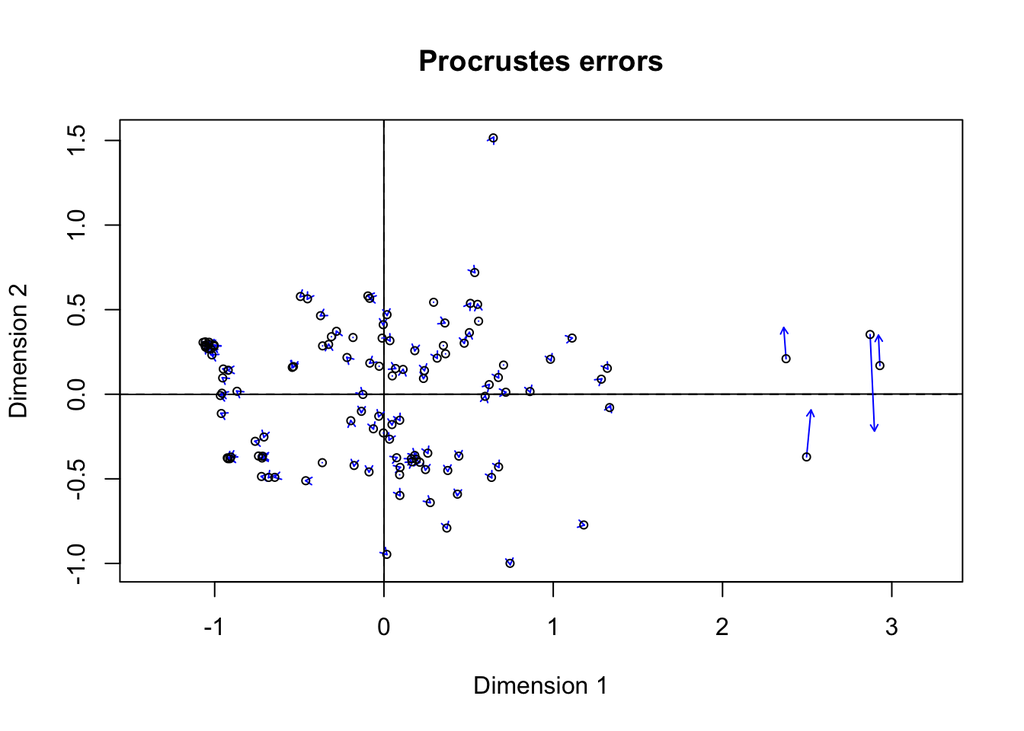

```r
# Scale solutions ("fix translation, rotation and scale")
mds.null.vir <- postMDS(mds.null.vir, virdist)
mds.1.vir <- postMDS(mds.1.vir, virdist)
# Compare solutions
plot(procrustes(mds.1.vir, mds.null.vir))
```

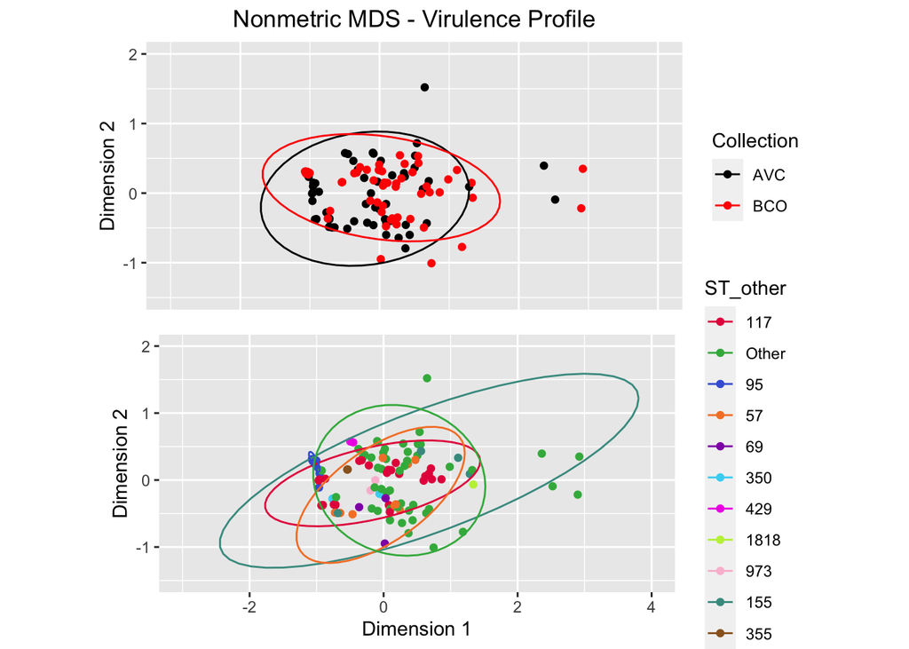

```r
#convert to dataframe
mds.null.vir.df <- as.data.frame(mds.null.vir,
                             attr(x = mds.null.vir,
                                which = "dimnames"))
mds.1.vir.df <- as.data.frame(mds.1.vir,
                          attr(x = mds.1.vir,
                              which = "dimnames"))

mds.1.vir$points %>% rownames() -> mds.1.vir.df$Name
mds.1.vir.df <- left_join(mds.1.vir.df, mds.metadata)

mds.1.vir.df$ST <- as.factor(mds.1.vir.df$ST)

#Virulence by Sequence Type
b1 <- ggplot() +
  geom_point(data=mds.1.vir.df,
             aes(x=points.1,
                 y=points.2,
                 color = Collection),
             size = 1.5) + # add the point markers
  stat_ellipse(aes(x=mds.1.vir.df$points.1,
                   y=mds.1.vir.df$points.2,
                   color = mds.1.vir.df$Collection)) +
  scale_color_manual(breaks = collection_names, values = collection_colours)+
  ggtitle("Nonmetric MDS - Virulence Profile")+
  xlab("Dimension 1")+
  ylab("Dimension 2")+
  coord_equal(xlim = c(-3, 4), ylim = c(-1.5, 2)) +
  theme(plot.title = element_text(hjust = 0.5),
        axis.title.x=element_blank(),
        axis.text.x=element_blank(),
        axis.ticks.x=element_blank())

b2 <- ggplot() +
  geom_point(data=mds.1.vir.df,
             aes(x=points.1,
                 y=points.2,
                 color = ST_other),
             size = 1.5) + # add the point markers
  stat_ellipse(aes(x=mds.1.vir.df$points.1,
                   y=mds.1.vir.df$points.2,
                   color = mds.1.vir.df$ST_other)) +
  scale_color_manual(breaks = ST_other_names, values = ST_other_cols)+
  xlab("Dimension 1")+
  ylab("Dimension 2")+
  coord_equal(xlim = c(-3, 4), ylim = c(-1.5, 2)) +
  theme(plot.title = element_text(hjust = 0.5))

grid.arrange(b1, b2, nrow = 2)
```

## Resistance NMDS

```r
mds.data <- genometa
rownames(mds.data) <- genometa %>% pull(name)
mds.metadata <- mds.data %>% dplyr::select(1:13, ST_other, EC_custom_intI1_HQ730118.1) %>% rename('Name' = 'name', 'intI1 carriage' = EC_custom_intI1_HQ730118.1) %>% mutate(`intI1 carriage` = as.character(`intI1 carriage`))

#read data into variable data
card_df <- genometa %>% dplyr::select(name, starts_with("card_")) %>% column_to_rownames('name')

card_df_MDS <- unique.data.frame(card_df)

#VIRULENCE
#create distance object
carddist <- vegdist(wisconsin(card_df_MDS), method = "jaccard")
# Get the baseline solution: start with cmdscale
mds.null.card <- isoMDS(carddist, tol=1e-7)
## See if you can get any better.
  repeat{
    mds.1.card <- isoMDS(carddist, k=2, initMDS(carddist, k = 2), maxit=200, trace=FALSE, tol=1e-7)
    print(mds.1.card$stress)
    print(mds.null.card$stress)
    if(mds.1.card$stress < mds.null.card$stress) break
  }
```

```
## [1] 16.30348
## [1] 16.12991
## [1] 15.41569
## [1] 16.12991
```

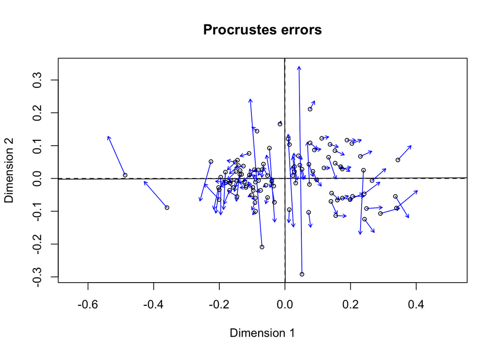

```r
# Scale solutions ("fix translation, rotation and scale")
mds.null.card <- postMDS(mds.null.card, carddist)
mds.1.card <- postMDS(mds.1.card, carddist)
# Compare solutions
plot(procrustes(mds.1.card, mds.null.card))
```

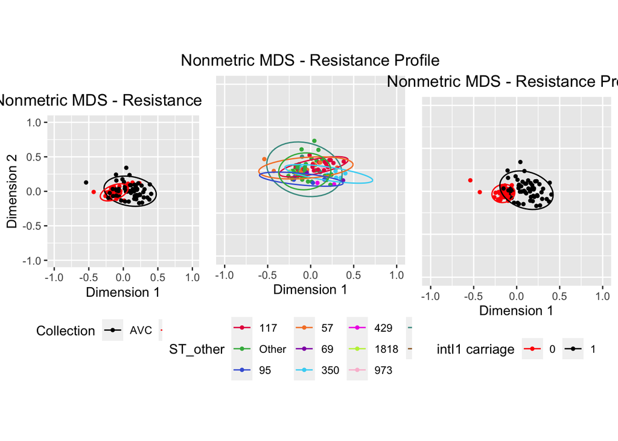

```r
#convert to dataframe
mds.null.card.df <- as.data.frame(mds.null.card,
                             attr(x = mds.null.card,
                                which = "dimnames"))
mds.1.card.df <- as.data.frame(mds.1.card,
                          attr(x = mds.1.card,
                              which = "dimnames"))

mds.1.card$points %>% rownames() -> mds.1.card.df$Name
mds.1.card.df <- left_join(mds.1.card.df, mds.metadata)

mds.1.card.df$ST <- as.factor(mds.1.card.df$ST)

#Virulence by Sequence Type
res_b1 <- ggplot() +
  geom_point(data=mds.1.card.df,
             aes(x=points.1,
                 y=points.2,
                 color = Collection),
             size = 1) + # add the point markers
  stat_ellipse(aes(x=mds.1.card.df$points.1,
                   y=mds.1.card.df$points.2,
                   color = mds.1.card.df$Collection)) +
  scale_color_manual(breaks = collection_names, values = collection_colours)+
  ggtitle("Nonmetric MDS - Resistance Profile")+
  xlab("Dimension 1")+
  ylab("Dimension 2")+
  coord_equal(xlim = c(-1, 1), ylim = c(-1, 1)) +
  theme(plot.title = element_text(hjust = 0.5), legend.position = "bottom")

res_b2 <- ggplot() +
  geom_point(data=mds.1.card.df,
             aes(x=points.1,
                 y=points.2,
                 color = ST_other),
             size = 1) + # add the point markers
  stat_ellipse(aes(x=mds.1.card.df$points.1,
                   y=mds.1.card.df$points.2,
                   color = mds.1.card.df$ST_other)) +
  scale_color_manual(breaks = ST_other_names, values = ST_other_cols)+
  ggtitle("Nonmetric MDS - Resistance Profile")+
  xlab("Dimension 1")+
  ylab("Dimension 2")+
  coord_equal(xlim = c(-1, 1), ylim = c(-1, 1)) +
  theme(plot.title = element_text(hjust = 0.5),
        legend.position = "bottom",
        axis.title.y=element_blank(),
        axis.text.y=element_blank(),
        axis.ticks.y=element_blank())

res_b3 <- ggplot() +
  geom_point(data=mds.1.card.df,
             aes(x=points.1,
                 y=points.2,
                 color = `intI1 carriage`),
             size = 1) + # add the point markers
  stat_ellipse(aes(x=mds.1.card.df$points.1,
                   y=mds.1.card.df$points.2,
                   color = mds.1.card.df$`intI1 carriage`)) +
  scale_color_manual(breaks = c('0','1'), values = c('red', 'black'))+
  ggtitle("Nonmetric MDS - Resistance Profile")+
  xlab("Dimension 1")+
  ylab("Dimension 2")+
  coord_equal(xlim = c(-1, 1), ylim = c(-1, 1)) +
  theme(plot.title = element_text(hjust = 0.5),
        legend.position = "bottom",
        axis.title.y=element_blank(),
        axis.text.y=element_blank(),
        axis.ticks.y=element_blank())

ggpubr::ggarrange(res_b1, res_b2, res_b3, nrow = 1, legend = "bottom")
```

```r
fit.mds <- vegan::metaMDS(comm = dist(vir_df), distance = "jaccard")
```

```
## *** Best solution repeated 1 times
```

```r
data.scores <- as.data.frame(scores(fit.mds))  #Using the scores function from vegan to extract the site scores and convert to a data.frame
data.scores$name <- rownames(data.scores)  # create a column of site names, from the rownames of data.scores

data.scores <- genometa %>% dplyr::select(1:13, ST_other) %>% inner_join(data.scores)

head(data.scores) #look at the data
```

```
##    name QC_Pass Exclude (non/duplicate sample) Final_subset
## 1 FH110    PASS                        Include           No
## 2 FH118    FAIL                        Include          Yes
## 3 FH131    FAIL                        Include           No
## 4 FH135    PASS                        Include           No
## 5 FH111    PASS                        Include           No
## 6 FH113    PASS                        Include           No
##   Bird_Gross_Necropsy_ID Plate Label - Site of isolation collection_date
## 1                    264                           LIVER       24/5/2016
## 2                    267                             RFH       24/5/2016
## 3                    360                           LIVER       24/5/2016
## 4                    362                              YS       24/5/2016
## 5                    264                             LFH       24/5/2016
## 6                    264                             LTT       24/5/2016
##   collection_year Bird_Age Farms_ID Flock_ID    Host Collection ST_other
## 1            2016        5        3       19 Chicken        BCO      355
## 2            2016        5        3       19 Chicken        BCO    Other
## 3            2016        5        3       19 Chicken        BCO    Other
## 4            2016        5        3       19 Chicken        BCO    Other
## 5            2016        5        3       19 Chicken        BCO      355
## 6            2016        5        3       19 Chicken        BCO      355
##        NMDS1     NMDS2
## 1 -0.8644418 2.0278211
## 2  1.0835258 0.9127243
## 3  0.5338694 1.2182010
## 4  0.4549773 1.0008423
## 5 -0.7915698 1.9390613
## 6 -0.8644418 2.0278211
```

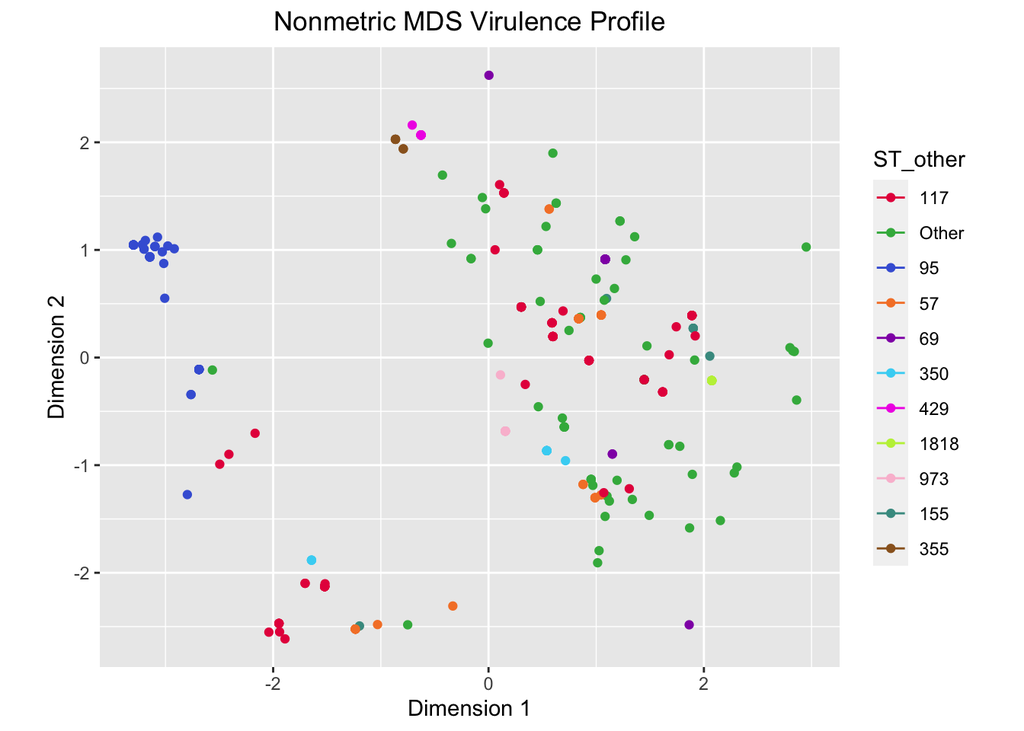

```r
ggplot() +
  geom_point(data=data.scores,
             aes(x=NMDS1,
                 y=NMDS2,
                 color = ST_other),
             size = 1.5) + # add the point markers
  stat_ellipse(aes(x=data.scores$NMDS1,
                   y=data.scores$NMDS2,
                   color = data.scores$ST_other)) +
  scale_color_manual(breaks = ST_other_names, values = ST_other_cols)+
  ggtitle("Nonmetric MDS Virulence Profile")+
  xlab("Dimension 1")+
  ylab("Dimension 2")+
  coord_equal() +
  theme(plot.title = element_text(hjust = 0.5))
```

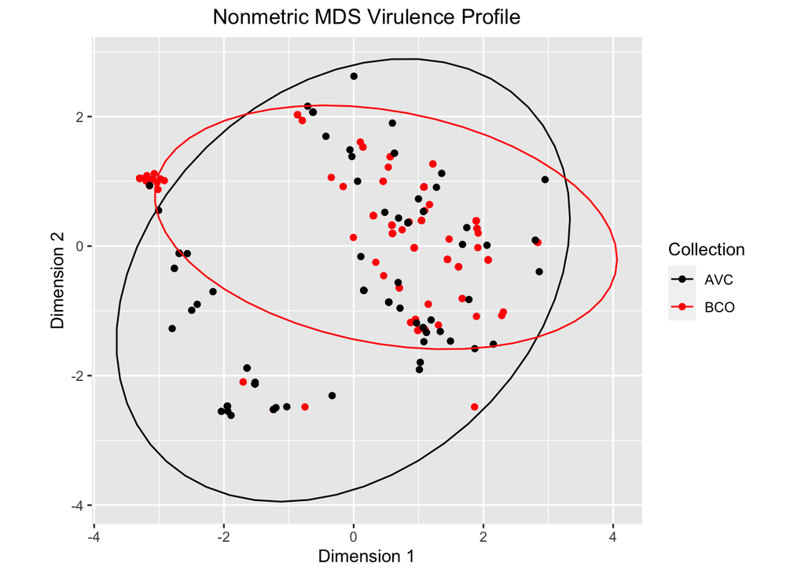

```r
ggplot() +
  geom_point(data=data.scores,
             aes(x=NMDS1,
                 y=NMDS2,
                 color = Collection),
             size = 1.5) + # add the point markers
  stat_ellipse(aes(x=data.scores$NMDS1,
                   y=data.scores$NMDS2,
                   color = data.scores$Collection)) +
  scale_color_manual(breaks = collection_names, values = collection_colours)+
  ggtitle("Nonmetric MDS Virulence Profile")+
  xlab("Dimension 1")+
  ylab("Dimension 2")+
  coord_equal() +
  theme(plot.title = element_text(hjust = 0.5))
```

```r
fit.mds <- vegan::metaMDS(comm = dist(vir_df), distance = "jaccard")
```

```
## *** Best solution repeated 1 times
```

```r
data.scores <- as.data.frame(scores(fit.mds))  #Using the scores function from vegan to extract the site scores and convert to a data.frame
data.scores$name <- rownames(data.scores)  # create a column of site names, from the rownames of data.scores

data.scores <- genometa %>% dplyr::select(1:13, ST_other) %>% inner_join(data.scores)

head(data.scores) #look at the data
```

```
##    name QC_Pass Exclude (non/duplicate sample) Final_subset
## 1 FH110    PASS                        Include           No
## 2 FH118    FAIL                        Include          Yes
## 3 FH131    FAIL                        Include           No
## 4 FH135    PASS                        Include           No
## 5 FH111    PASS                        Include           No
## 6 FH113    PASS                        Include           No
##   Bird_Gross_Necropsy_ID Plate Label - Site of isolation collection_date
## 1                    264                           LIVER       24/5/2016
## 2                    267                             RFH       24/5/2016
## 3                    360                           LIVER       24/5/2016
## 4                    362                              YS       24/5/2016
## 5                    264                             LFH       24/5/2016
## 6                    264                             LTT       24/5/2016
##   collection_year Bird_Age Farms_ID Flock_ID    Host Collection ST_other
## 1            2016        5        3       19 Chicken        BCO      355
## 2            2016        5        3       19 Chicken        BCO    Other
## 3            2016        5        3       19 Chicken        BCO    Other
## 4            2016        5        3       19 Chicken        BCO    Other
## 5            2016        5        3       19 Chicken        BCO      355
## 6            2016        5        3       19 Chicken        BCO      355
##        NMDS1     NMDS2
## 1 -0.8639066 2.0281136
## 2  1.0835458 0.9128321
## 3  0.5336624 1.2183462
## 4  0.4556339 1.0010129
## 5 -0.7918128 1.9389230
## 6 -0.8639066 2.0281136
```

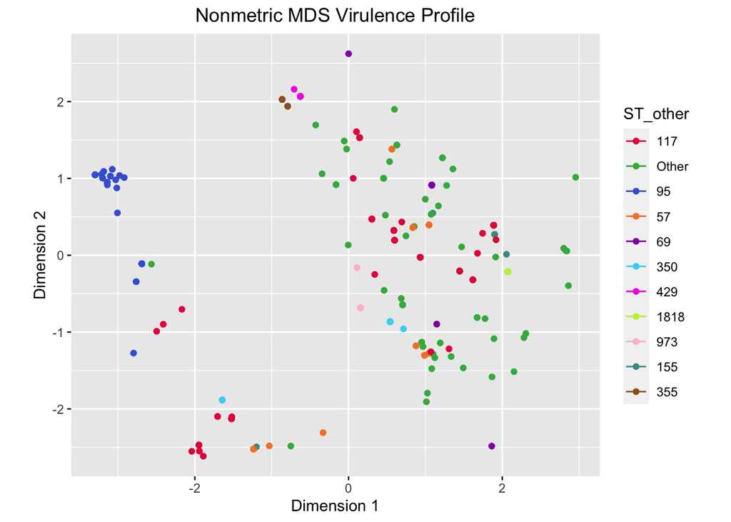

```r
ggplot() +
  geom_point(data=data.scores,
             aes(x=NMDS1,
                 y=NMDS2,
                 color = ST_other),
             size = 1.5) + # add the point markers
  stat_ellipse(aes(x=data.scores$NMDS1,
                   y=data.scores$NMDS2,
                   color = data.scores$ST_other)) +
  scale_color_manual(breaks = ST_other_names, values = ST_other_cols)+
  ggtitle("Nonmetric MDS Virulence Profile")+
  xlab("Dimension 1")+
  ylab("Dimension 2")+
  coord_equal() +
  theme(plot.title = element_text(hjust = 0.5))
```

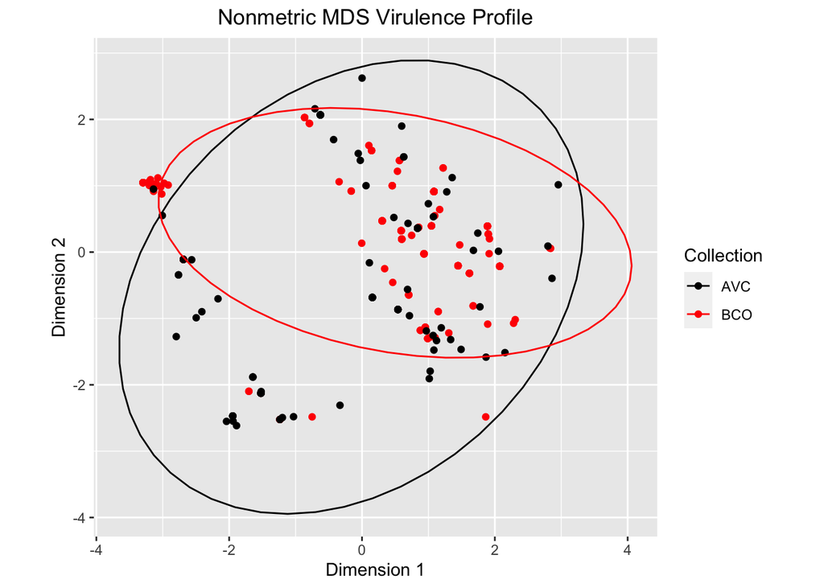

```r
ggplot() +
  geom_point(data=data.scores,
             aes(x=NMDS1,
                 y=NMDS2,
                 color = Collection),
             size = 1.5) + # add the point markers
  stat_ellipse(aes(x=data.scores$NMDS1,
                   y=data.scores$NMDS2,
                   color = data.scores$Collection)) +
  scale_color_manual(breaks = collection_names, values = collection_colours) +
  ggtitle("Nonmetric MDS Virulence Profile")+
  xlab("Dimension 1")+
  ylab("Dimension 2")+
  coord_equal() +
  theme(plot.title = element_text(hjust = 0.5))
```

```r
#read data into variable data
mds.data <- genometa
rownames(mds.data) <- genometa %>% pull(name)
mds.metadata <- mds.data %>% dplyr::select(1:13, ST_other) %>% rename('Name' = 'name')

is_df <- genometa %>% dplyr::select(starts_with("ISfinder"))

rownames(is_df) <- genometa$name

is_df_MDS <- unique.data.frame(is_df)

#VIRULENCE
#create distance object
ISdist <- vegdist(wisconsin(is_df_MDS), method = "jaccard")
# Get the baseline solution: start with cmdscale
mds.null.IS <- isoMDS(ISdist, tol=1e-7)
## See if you can get any better.
  repeat{
    mds.1.IS <- isoMDS(ISdist, k=2, initMDS(ISdist, k = 2), maxit=200, trace=FALSE, tol=1e-7)
    print(mds.1.IS$stress)
    print(mds.null.IS$stress)
    if(mds.1.IS$stress < mds.null.IS$stress) break
  }
```

```
## [1] 32.11337
## [1] 29.16793
## [1] 29.9316
## [1] 29.16793
## [1] 29.10391
## [1] 29.16793
```

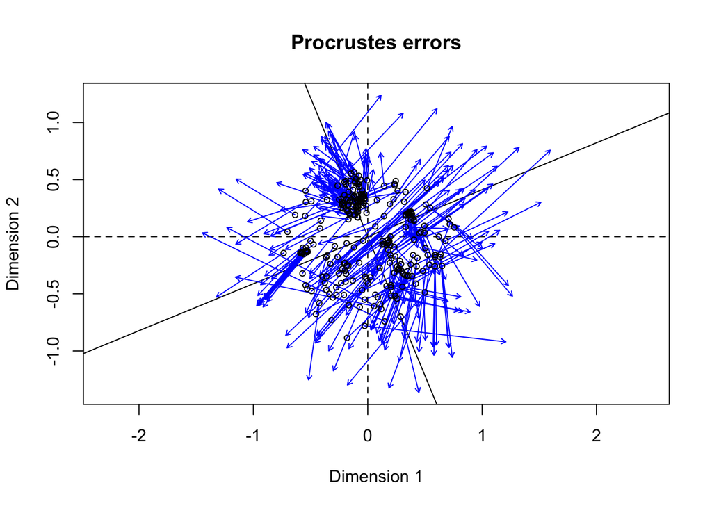

```r
# Scale solutions ("fix translation, rotation and scale")
mds.null.IS <- postMDS(mds.null.IS, ISdist)
mds.1.IS <- postMDS(mds.1.IS, ISdist)
# Compare solutions
plot(procrustes(mds.1.IS, mds.null.IS))
```

```r
#convert to dataframe
mds.null.IS.df <- as.data.frame(mds.null.IS,
                             attr(x = mds.null.IS,
                                which = "dimnames"))
mds.1.IS.df <- as.data.frame(mds.1.IS,
                          attr(x = mds.1.IS,
                              which = "dimnames"))

mds.1.IS$points %>% rownames() -> mds.1.IS.df$Name
mds.1.IS.df <- left_join(mds.1.IS.df, mds.metadata)

mds.1.IS.df$ST <- as.factor(mds.1.IS.df$ST)

#Virulence by Sequence Type
b1 <- ggplot() +
  geom_point(data=mds.1.IS.df,
             aes(x=points.1,
                 y=points.2,
                 color = Collection),
             size = 1.5) + # add the point markers
  stat_ellipse(aes(x=mds.1.IS.df$points.1,
                   y=mds.1.IS.df$points.2,
                   color = mds.1.IS.df$Collection)) +
  scale_color_manual(breaks = collection_names, values = collection_colours)+
  ggtitle("Nonmetric MDS Virulence Profile")+
  xlab("Dimension 1")+
  ylab("Dimension 2")+
  coord_equal() +
  theme(plot.title = element_text(hjust = 0.5))

b2 <- ggplot() +
  geom_point(data=mds.1.IS.df,
             aes(x=points.1,
                 y=points.2,
                 color = ST_other),
             size = 1.5) + # add the point markers
  stat_ellipse(aes(x=mds.1.IS.df$points.1,
                   y=mds.1.IS.df$points.2,
                   color = mds.1.IS.df$ST_other)) +
  scale_color_manual(breaks = ST_other_names, values = ST_other_cols)+
  ggtitle("Nonmetric MDS Virulence Profile")+
  xlab("Dimension 1")+
  ylab("Dimension 2")+
  coord_equal() +
  theme(plot.title = element_text(hjust = 0.5))
```